# CurrentWorkingDraftGiardia

Anika Larson

5/29/2016

For this risk estimate, we will use mcmodel and evalmcmod from the [mc2d](https://cran.r-project.org/web/packages/mc2d/index.html) package.

```r
# Load packages.
library(mc2d)
library(data.table)
library(sfsmisc)
```

```r
library(graphics)
```

### Define variables

Set the number of simulations for the variability and uncertainty dimensions.

```r
nsv <- 360
nsu <- 420
ndvar(nsv)  # Variability
```

```
## [1] 360
```

```r
ndunc(nsu)   # Uncertainty
```

```
## [1] 420
```

```r
rdv <- (nsu/3)
cwv <- (nsu/4)
div.nsv <- (nsv/3)
div5.nsv <- (nsv/5)
div5.nsu <- (nsu/5)
div7.nsu <- (nsu/7)
ns <- nsu * nsv
```

The *mc2d* functions will set `nsv` to `ndvar()` and `nsu` to `ndunc()` by default. Alternatively, we could supply these values to the *mc2d* model functions when we call them.

Define the variables we will use to set the `seed` for random sampling and the number of `digits` for `print()` statements.

```r
seed <- 1
digits <- 5
```

Introducing the bootstrapped dose-response data, fread command and sampling from Brian:

```r
klist <- fread("output_rendtorff_giardia/klist.csv", sep = ',')
gdrk <- klist[sample(nrow(klist), nsu, replace = TRUE), list(x)] #sampling rows in the dose-response bootstrapped table equal to the number of simulations in the uncertainty dimension, aka NSU
```

Sampling from the Giardia Crabtree custom distribution estimates:

```r
#Using the original custom distribution of estimates from aggregated cistern estimates:
cw.vlg1 <- fread("conc_data_aggreg.csv", sep = ',')
cw.vl.samp.1 <- sample(cw.vlg1[,c(cysts)], nsu, replace = TRUE)

#Using a combination of log-normal distributions from each of the the 5 different cisterns:
cw.vl.ln <- fread("concdata_percis.csv", sep = ',')
v1 <- cw.vl.ln[sample(nrow(cw.vl.ln), div7.nsu, replace = TRUE), list(g_v1_ln)]
colnames(v1) <- c("cw.vals")
v11 <- cw.vl.ln[sample(nrow(cw.vl.ln), div7.nsu, replace = TRUE), list(g_v11_ln)]
colnames(v11) <- c("cw.vals")
v2 <- cw.vl.ln[sample(nrow(cw.vl.ln), div7.nsu, replace = TRUE), list(g_v2_ln)]
colnames(v2) <- c("cw.vals")
v5 <- cw.vl.ln[sample(nrow(cw.vl.ln), div7.nsu, replace = TRUE), list(g_v5_ln)]
colnames(v5) <- c("cw.vals")
v9 <- cw.vl.ln[sample(nrow(cw.vl.ln), div7.nsu, replace = TRUE), list(g_v9a_ln)]
colnames(v9) <- c("cw.vals")
v10 <- cw.vl.ln[sample(nrow(cw.vl.ln), div7.nsu, replace = TRUE), list(g_v10_ln)]
colnames(v5) <- c("cw.vals")
v8 <- cw.vl.ln[sample(nrow(cw.vl.ln), div7.nsu, replace = TRUE), list(g_v8a_ln)]
colnames(v9) <- c("cw.vals")
cw.vlg2 <- unlist(c(v1$cw.vals,v11$cw.vals,v2$cw.vals,v5$cw.vals,v9$cw.vals,v10$cw.vals,v8$cw.vals))
cw.vl.samp2 <- sample(cw.vlg2, nsu, replace = TRUE)

#Determine which estimate to use: the original custom distribution (cw.vl.samp1) or the combined lognormal ditributions for each cistern (cw.vl.samp2).
cw.vl.samp <- cw.vl.samp2
```

```r
  #pfc_reduc set using the distribution
  gcfilt <- fread("cer_filts/CerFiltGiardia.csv", sep = ',')
  colnames(gcfilt) <- c("trial","logr")
  gcfilt$reduc <- 10^(-gcfilt$logr)
  pfc_reduc2 <- gcfilt[sample(nrow(gcfilt), nsu, replace = TRUE), list(reduc)]
```

Sampling from the distribution of the estimates of Crypto reduction by porous ceramic filtration, and converting them from log reduction to percent reduction:

```r
  #pfc_reduc set using the distribution
  gcfilt <- fread("cer_filts/CerFiltCrypto.csv", sep = ',')
  colnames(gcfilt) <- c("trial","logr")
  gcfilt$reduc <- (1 - (10^(-gcfilt$logr)))
  pfc_reduc2 <- gcfilt[sample(nrow(gcfilt), nsu, replace = TRUE), list(reduc)]
```

Sampling from the daily hosing exposure estimates distribution:

```r
  #Creating a distribution for hosing
  hose <- fread("exp_params/Hosing.csv", sep = ',')
  colnames(hose) <- c("trial","num", "mL")
  hose$hose_exp1 <- (hose$num * hose$mL)
  hose_exp <- hose[sample(nrow(hose), nsu, replace = TRUE), list(hose_exp1)]
```

Sampling from the daily showering exposure estimates distribution:

```r
  #Creating a distribution for showering
  shower <- fread("exp_params/Showers.csv", sep = ',')
  colnames(shower) <- c("trial","num", "mL")
  shower$shower_exp1 <- (shower$num * shower$mL)
  shower_exp <- shower[sample(nrow(shower), nsu, replace = TRUE), list(shower_exp1)]
```

We will use this variable to explicitly set the seed with the various *mc2d* functions. Another approach would be to only set it through the model evaluation functions, or not at all. Since we want to do our best to provide the most reproducible results, we set the seed explicitly.

### Define exposure model

Within the mcmodel function, use mcstoc to define “mc nodes” for each component of the model.

For each stochastic variable, use the `mcstoc()` function to create a “mcnode”, supply a probability function, the node type as “V” for variability, “U” for uncertainty, or “VU” for both, and any additional parameters to be passed to the probability function.

For deterministic variables, create nodes with the `mcdata()` function using the “0” type.

The last statement makes an “mc” object using the mc function.

```r
# Define an exposure model for evaluation by evalmcmod().
expo.mod1 <- mcmodel({
  # Values from Example 6.18 from Quantitative Microbial Risk Assessment,
  # 2nd Edition by Charles N. Haas, Joan B. Rose, and Charles P. Gerba.
  # (Wiley, 2014), pp. 215-216. Other fictitious values are noted below.

  #Setting options for cistern water viral loading (viruses/L):
  cw.vl1 <- mcdata(cw.vl.samp, type = "U")
  cw.vl2 <- mcstoc(rempiricalD, type = "V", values = cw.vl.samp)
  cw.vl3 <- mcstoc(rempiricalD, type = "VU", values = cw.vl.samp)
  #Defining cistern water viral loading:
  cw.vl <- cw.vl3

  #Setting options for water consumption (L/day):
  dw.ing1 <- mcdata(1.466, type = "U")
  dw.ing2 <- mcstoc(rpois, type = "VU", lambda = 1.466)
  dw.ing <- dw.ing1

  #Setting options for hosing per event ingestion rate (L/event): worst case estimate = 10mL or .01L per day
  hose.perevent <- mcdata(.01, type = "U")
  hose.perevent.dis <- mcdata(hose_exp$hose_exp1, type = "U")
  #Daily hosing exposure sampling from distribution
  daily_hose_exp <- mcstoc(rempiricalD, type = "V", values = hose_exp$hose_exp1)
  hosing <- hose.perevent

   # Showering per event ingestion rate (L/event): worst case estimate = 10mL or .01L per day
  shower.perevent <- mcdata(.01, type = "U")
  shower.perevent.dis <- mcdata(shower_exp$shower_exp1, type = "U")
  #Daily showering sampling from distribution:
  daily_shower_exp <- mcstoc(rempiricalD, type = "V", values = shower_exp$shower_exp1)
  shower <- daily_shower_exp

  # Estimate the exposure based ONLY on drinking water ingestion using the 0, V and U nodes to create a VU node.
  exporaw.mc1 <- (cw.vl * (dw.ing + hosing + shower))

  #Reduction by free chlorine at 5ppm - this is based on the "range" of values from 99% reduction to 99.8% reduction as continuous distribution:
  fc_reduc <- mcstoc(rempiricalC, type = "V", n = 440, values = c(.001, .01), min = .001, max = .01)
  exporaw.5ppm_fcl <- (exporaw.mc1 * fc_reduc)

  #Reduction by UV, no variability or uncertainty:
  exporaw.uv <- (exporaw.mc1 * .0001)

    #Reduction by porous ceramic filtration based on the distribution entered lines 93-99:
  pfc_reduc <- mcstoc(rempiricalD, type = "V", values = pfc_reduc2$reduc)
  exporaw.pfc_reduc <- (exporaw.mc1 * pfc_reduc)

  #Reduction by porous ceramic filtration AND free chlorine 5ppm:
  exporaw.fcl_pfc <- (exporaw.mc1 * pfc_reduc * fc_reduc)

    #Defining the exposure to be used for the current trial, depending on the filtration / purification wanted:
  expo.mc1 <- exporaw.5ppm_fcl

  #Estimate the risk using a dose-response model pulling from a bootstrapped model of the dose-response
  dose1 <- expo.mc1
  dose2 <- mcstoc(rpois, type = "VU", lambda = expo.mc1)
  dose <- dose1

  #Drawing from the bootstrapped distribution of k-values made in Crystal Ball:
  k1 <- mcdata(gdrk$x, type = "U")
  k2 <- mcstoc(rempiricalD, type = "VU", values = pfc_reduc2$reduc)
  k <- k1

  risk <- (1 - exp(-dose*k)) #this equation is my version an exponential DR equation from what came off QMRA Wiki <http://qmrawiki.canr.msu.edu/index.php?title=Dose_response_assessment> and someone please check it -A

  #Setting the yearly risk:
  yearrisk <- 1 - ((1 - risk)^365)

  # Build a mc model from all of the mcnode objects.
  mc(cw.vl1, cw.vl2, cw.vl3, cw.vl, dw.ing1, dw.ing2, dw.ing, hosing, shower, k1, k2, k, exporaw.mc1, exporaw.5ppm_fcl, fc_reduc, pfc_reduc, exporaw.pfc_reduc, exporaw.uv, expo.mc1, risk, yearrisk)
})
```

### Evaluate the model

```r
expo.ev1 <- evalmcmod(expo.mod1, seed = seed)
print(expo.ev1, digits = digits)
```

```
##                 node    mode nsv nsu nva variate        min       mean
## 1             cw.vl1 numeric   1 420   1       1 3.8200e-05 6.2191e-03
## 2             cw.vl2 numeric 360   1   1       1 3.8200e-05 6.0215e-03
## 3             cw.vl3 numeric 360 420   1       1 3.8200e-05 6.2376e-03
## 4              cw.vl numeric 360 420   1       1 3.8200e-05 6.2376e-03
## 5            dw.ing1 numeric   1 420   1       1 1.4660e+00 1.4660e+00
## 6            dw.ing2 numeric 360 420   1       1 0.0000e+00 1.4689e+00
## 7             dw.ing numeric   1 420   1       1 1.4660e+00 1.4660e+00
## 8             hosing numeric   1 420   1       1 1.0000e-02 1.0000e-02
## 9             shower numeric 360   1   1       1 0.0000e+00 1.3236e+01
## 10                k1 numeric   1 420   1       1 8.5047e-03 2.0649e-02
## 11                k2 numeric 360 420   1       1 8.4512e-01 9.8362e-01
## 12                 k numeric   1 420   1       1 8.5047e-03 2.0649e-02
## 13       exporaw.mc1 numeric 360 420   1       1 5.6383e-05 9.1773e-02
## 14  exporaw.5ppm_fcl numeric 360 420   1       1 6.9715e-08 4.8627e-04
```

[output cut: 29 more lines]

### Summarize results

Print a summary and a plot of the evaluation results (`expo.ev1`).

```r
# Summarize the results.
summary(expo.ev1)
```

```
## cw.vl1 :
##           NoVar
## median 3.18e-03
## mean   6.22e-03
## 2.5%   7.91e-05
## 97.5%  3.97e-02
##
## cw.vl2 :
##          mean      sd      Min     2.5%   25%     50%     75%  97.5%
## NoUnc 0.00602 0.00881 3.82e-05 0.000187 0.001 0.00304 0.00734 0.0352
##          Max nsv Na's
## NoUnc 0.0714 360    0
##
## cw.vl3 :
##           mean      sd      Min     2.5%      25%     50%     75%  97.5%
## median 0.00621 0.00949 3.82e-05 8.53e-05 0.001010 0.00317 0.00696 0.0397
## mean   0.00624 0.00948 4.30e-05 1.06e-04 0.001010 0.00310 0.00707 0.0398
## 2.5%   0.00528 0.00768 3.82e-05 7.21e-05 0.000829 0.00252 0.00639 0.0241
## 97.5%  0.00720 0.01128 7.21e-05 2.31e-04 0.001250 0.00360 0.00780 0.0485
##           Max nsv Na's
## median 0.0714 360    0
## mean   0.0624 360    0
## 2.5%   0.0485 360    0
## 97.5%  0.0714 360    0
##
## cw.vl :
##           mean      sd      Min     2.5%      25%     50%     75%  97.5%
## median 0.00621 0.00949 3.82e-05 8.53e-05 0.001010 0.00317 0.00696 0.0397
## mean   0.00624 0.00948 4.30e-05 1.06e-04 0.001010 0.00310 0.00707 0.0398
## 2.5%   0.00528 0.00768 3.82e-05 7.21e-05 0.000829 0.00252 0.00639 0.0241
## 97.5%  0.00720 0.01128 7.21e-05 2.31e-04 0.001250 0.00360 0.00780 0.0485
##           Max nsv Na's
## median 0.0714 360    0
## mean   0.0624 360    0
## 2.5%   0.0485 360    0
## 97.5%  0.0714 360    0
##
## dw.ing1 :
##        NoVar
## median  1.47
```

[output cut: 128 more lines]

```
## mean   6.93e-05 0.000304 360    0
## 2.5%   3.25e-05 0.000103 360    0
## 97.5%  1.32e-04 0.000801 360    0
##
## yearrisk :
##           mean      sd      Min     2.5%      25%      50%     75%  97.5%
## median 0.00339 0.00836 2.27e-06 1.56e-05 0.000207 0.000798 0.00291 0.0229
## mean   0.00360 0.00919 2.65e-06 1.64e-05 0.000222 0.000839 0.00304 0.0249
## 2.5%   0.00194 0.00430 6.16e-07 7.21e-06 0.000112 0.000429 0.00160 0.0118
## 97.5%  0.00639 0.01793 6.42e-06 3.16e-05 0.000381 0.001446 0.00514 0.0471
##           Max nsv Na's
## median 0.0889 360    0
## mean   0.1033 360    0
## 2.5%   0.0371 360    0
## 97.5%  0.2534 360    0
```

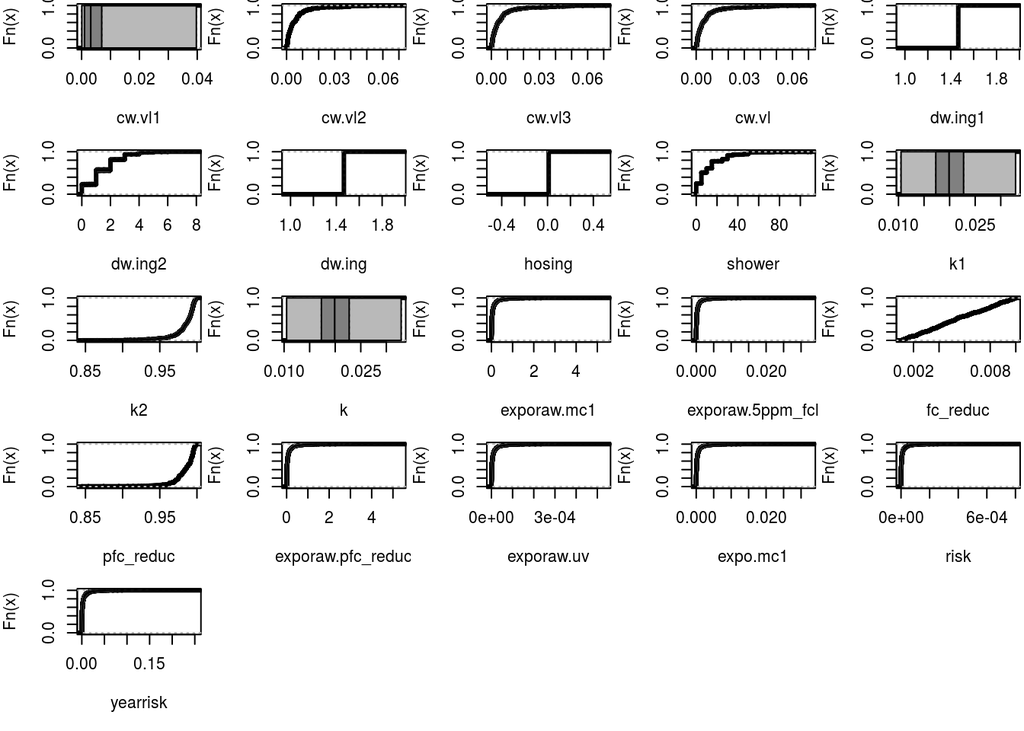

```r
# Plot the results.
plot(expo.ev1)
```

Report the mean and median of the DAILY risk probability means with a 95% confidence interval (CI95).

```r
mean.risk <- sapply(1:ndunc(), function(j) mean(expo.ev1$risk[, j, ]))
mean(mean.risk)
```

```
## [1] 1.003705e-05
```

```r
quantile(mean.risk, probs = seq(0, 1, 0.025))[c("2.5%", "50%", "97.5%")]
```

```
##         2.5%          50%        97.5%
## 5.345573e-06 9.400620e-06 1.796719e-05
```

Report the mean and median of the YEARLY risk probability means with a 95% confidence interval (CI95).

```r
mean.yearrisk <- sapply(1:ndunc(), function(j) mean(expo.ev1$yearrisk[, j, ]))
mean(mean.yearrisk)
```

```
## [1] 0.00360398
```

```r
quantile(mean.yearrisk, probs = seq(0, 1, 0.025))[c("2.5%", "25%", "50%", "75%", "97.5%")]
```

```
##        2.5%         25%         50%         75%       97.5%
## 0.001940476 0.002790635 0.003392382 0.004196273 0.006393452
```

Plot the empirical cumulative distribution function (ecdf) of the exposure model (`expo.mc1`) estimates.

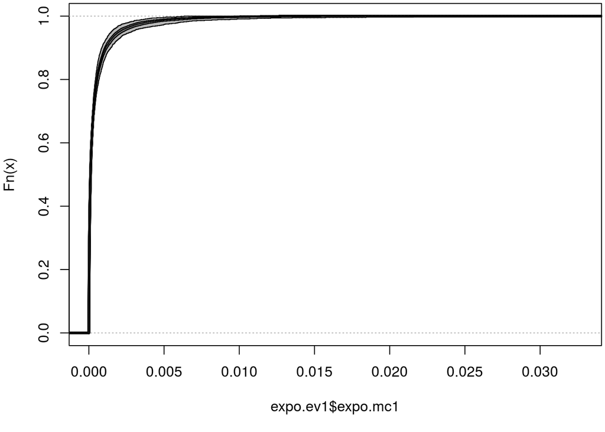

```r
# Generate an "ecdf" plot. This actually calls plot.mcnode().
plot(expo.ev1$expo.mc1)
```

Plot the empirical cumulative distribution function (ecdf) of the risk model (`risk`) estimates.

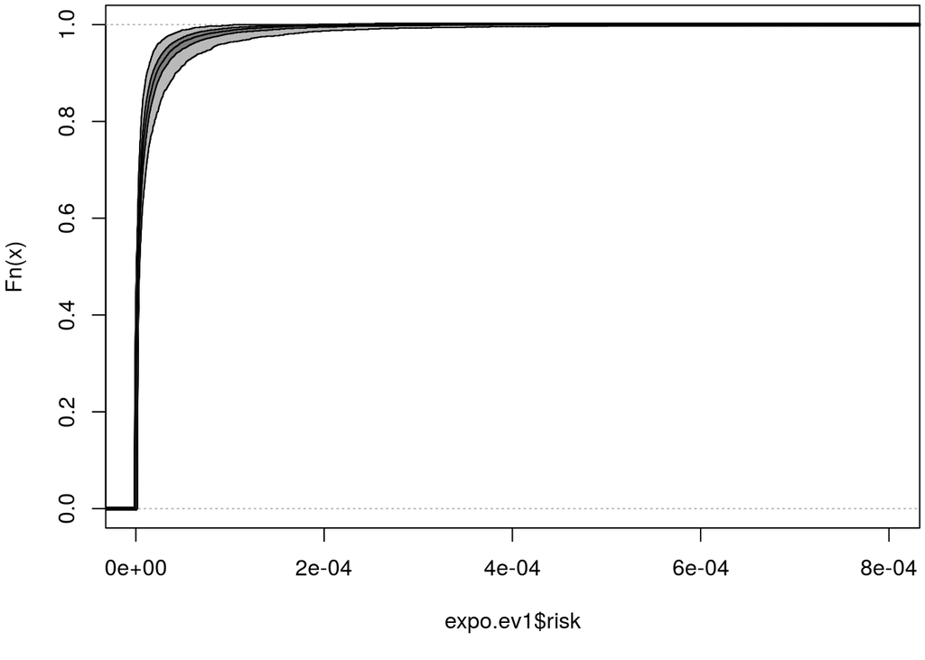

```r
# Generate an "ecdf" plot. This actually calls plot.mcnode().
plot(expo.ev1$risk)
```

Label the plot:

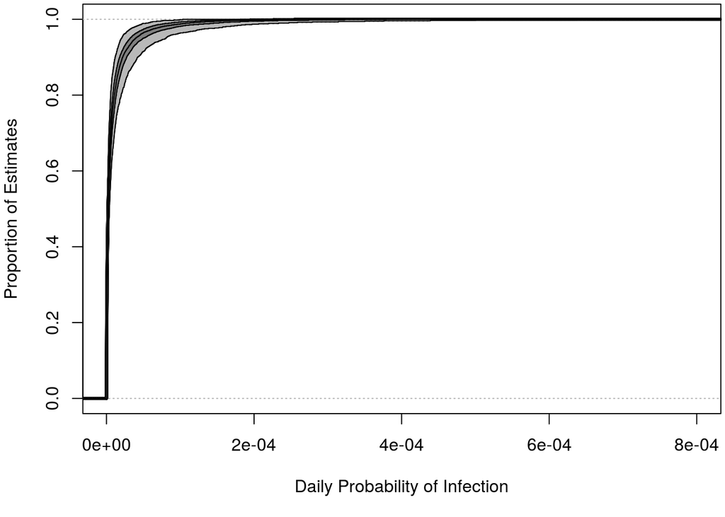

```r
# Generate an "ecdf" plot. This actually calls plot.mcnode().
plot(expo.ev1$risk, main = "", ylab = "Proportion of Estimates", xlab = "Daily Probability of Infection")
title("Daily Infec. Risk with Giardia by RCRW
in the USVI", cex.main = 1, font.main= 1, line = 7)
```

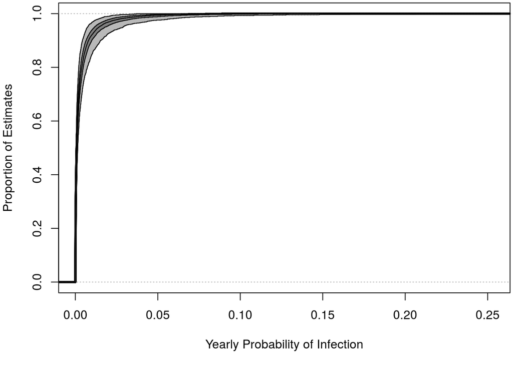

```r
# Generate an "ecdf" plot. This actually calls plot.mcnode().
plot(expo.ev1$yearrisk, main = "", ylab = "Proportion of Estimates", xlab = "Yearly Probability of Infection")
title("Yearly Infec. Risk with Giardia by RCRW
in the USVI", cex.main = 1, font.main= 1, line = 7)
```

Manually remake the graph, this time using yearrisk, which should just be another mcnode object with all values between 0 and 1:

The first one plots yearrisk without a log x scale:

```r
library(reshape)
```

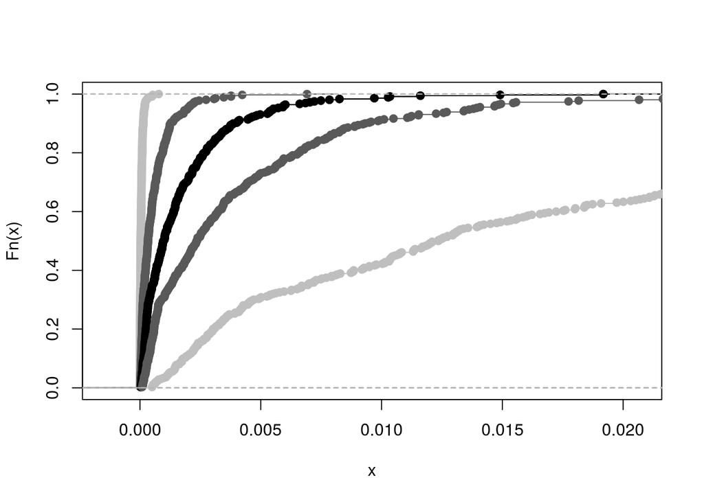

```r
library(ggplot2)
Risk.mat.1 <- expo.ev1$yearrisk[,,]
probs1 <- c(0.025, 0.25, 0.50, 0.75, 0.975)
quant1 <- as.data.frame(t(apply(Risk.mat.1, 1, quantile, probs = probs1)))
ecdfs1 <- sapply(names(quant1), function(q) ecdf(quant1[[q]]))
plot(ecdfs1[['50%']], main = '')
grays <- c('gray75', 'gray35', 'black', 'gray35', 'gray75')
lines <- mapply(function(e, g) lines(e, col = g), ecdfs1, grays)
```

Plotting yearrisk ECDF plot with ggplot2:

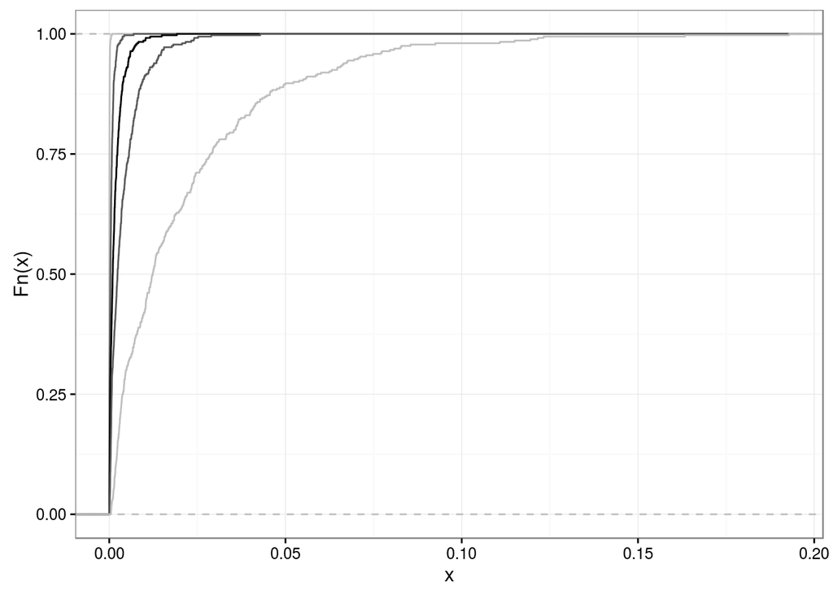

```r
quant.melt1 <- suppressMessages(melt(quant1))
names(quant.melt1) <- c('q', 'x')
grays <- c('gray75', 'gray35', 'black', 'gray35', 'gray75')
ggplot(quant.melt1, aes(x = x)) + theme_bw() + theme(legend.position = 'none') + geom_hline(yintercept = c(0, 1), linetype = "dashed", color = 'gray') + stat_ecdf(aes(group = q, color = q)) + xlab('x') + ylab('Fn(x)') + scale_colour_manual(values = grays)
```

Plot Version 2 with ggplot2, and a log-scale x axis:

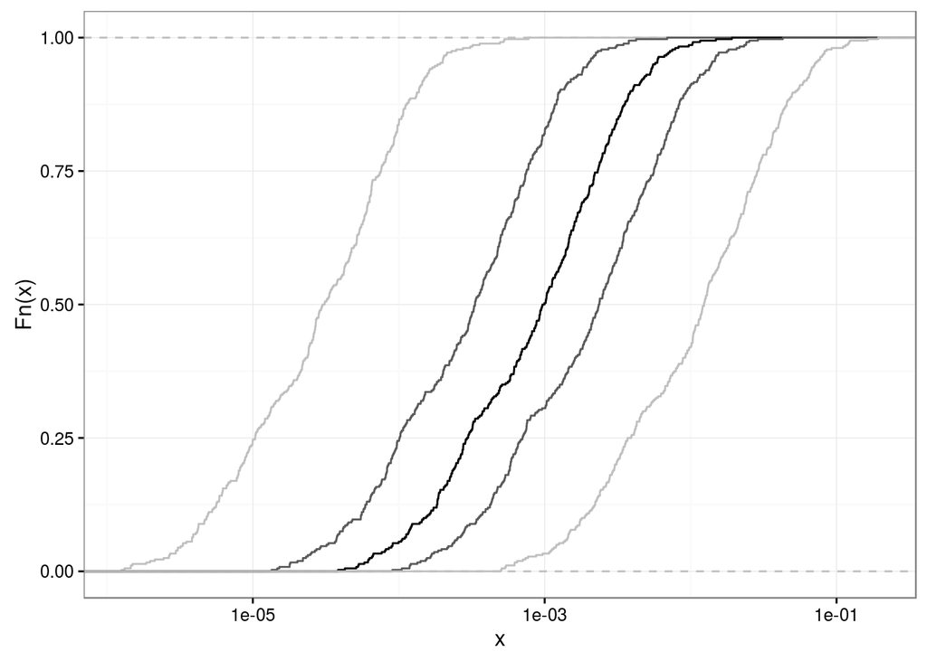

```r
quant.melt1 <- suppressMessages(melt(quant1))
names(quant.melt1) <- c('q', 'x')
grays <- c('gray75', 'gray35', 'black', 'gray35', 'gray75')
ggplot(quant.melt1, aes(x = x)) + theme_bw() + theme(legend.position = 'none') + geom_hline(yintercept = c(0, 1), linetype = "dashed", color = 'gray') + stat_ecdf(aes(group = q, color = q)) + xlab('x') + ylab('Fn(x)') + scale_colour_manual(values = grays) + scale_x_log10()
```